# (Visualizing FordGoBike Data)

## Introduction

This data set includes information about individual rides made in a bike-sharing system covering the greater San Francisco Bay area.

```python
# import all packages and set plots to be embedded inline
import numpy as np
import pandas as pd
import matplotlib.pyplot as plt
import seaborn as sb

%matplotlib inline
```

## Data Wrangling

> **Tip**: In this section of the report, will load in the data, check for cleanliness, and then trim and clean dataset for analysis.

```python
df = pd.read_csv('fordgobike.csv')
df.head()
```

|  | duration_sec | start_time | end_time | start_station_id | start_station_name | start_station_latitude | start_station_longitude | end_station_id | end_station_name | end_station_latitude | end_station_longitude | bike_id | user_type | member_birth_year | member_gender | bike_share_for_all_trip |
| --- | --- | --- | --- | --- | --- | --- | --- | --- | --- | --- | --- | --- | --- | --- | --- | --- |
| 0 | 52185 | 2019-02-28 17:32:10.1450 | 2019-03-01 08:01:55.9750 | 21.0 | Montgomery St BART Station (Market St at 2nd St) | 37.789625 | -122.400811 | 13.0 | Commercial St at Montgomery St | 37.794231 | -122.402923 | 4902 | Customer | 1984.0 | Male | No |
| 1 | 42521 | 2019-02-28 18:53:21.7890 | 2019-03-01 06:42:03.0560 | 23.0 | The Embarcadero at Steuart St | 37.791464 | -122.391034 | 81.0 | Berry St at 4th St | 37.775880 | -122.393170 | 2535 | Customer | NaN | NaN | No |
| 2 | 61854 | 2019-02-28 12:13:13.2180 | 2019-03-01 05:24:08.1460 | 86.0 | Market St at Dolores St | 37.769305 | -122.426826 | 3.0 | Powell St BART Station (Market St at 4th St) | 37.786375 | -122.404904 | 5905 | Customer | 1972.0 | Male | No |
| 3 | 36490 | 2019-02-28 17:54:26.0100 | 2019-03-01 04:02:36.8420 | 375.0 | Grove St at Masonic Ave | 37.774836 | -122.446546 | 70.0 | Central Ave at Fell St | 37.773311 | -122.444293 | 6638 | Subscriber | 1989.0 | Other | No |
| 4 | 1585 | 2019-02-28 23:54:18.5490 | 2019-03-01 00:20:44.0740 | 7.0 | Frank H Ogawa Plaza | 37.804562 | -122.271738 | 222.0 | 10th Ave at E 15th St | 37.792714 | -122.248780 | 4898 | Subscriber | 1974.0 | Male | Yes |

## Number of rows & columns in the dataset

- Based on the cell below, there are a totel of 183412 row of moives and 16 columns in the dataset.

```python
df.shape
```

```
(183412, 16)
```

```python
df.info()
```

```
<class 'pandas.core.frame.DataFrame'>
RangeIndex: 183412 entries, 0 to 183411
Data columns (total 16 columns):
 #   Column                   Non-Null Count   Dtype
---  ------                   --------------   -----
 0   duration_sec             183412 non-null  int64
 1   start_time               183412 non-null  object
 2   end_time                 183412 non-null  object
 3   start_station_id         183215 non-null  float64
 4   start_station_name       183215 non-null  object
 5   start_station_latitude   183412 non-null  float64
 6   start_station_longitude  183412 non-null  float64
 7   end_station_id           183215 non-null  float64
 8   end_station_name         183215 non-null  object
 9   end_station_latitude     183412 non-null  float64
 10  end_station_longitude    183412 non-null  float64
 11  bike_id                  183412 non-null  int64
 12  user_type                183412 non-null  object
 13  member_birth_year        175147 non-null  float64
 14  member_gender            175147 non-null  object
 15  bike_share_for_all_trip  183412 non-null  object
dtypes: float64(7), int64(2), object(7)
memory usage: 22.4+ MB
```

### What is the structure of your dataset?

Data related to Fordgobike trips from 01FEB 2019 till 01 MAR2019 & data included

- Trip Duration (seconds)
- Start Time and Date
- End Time and Date
- Start Station ID
- Start Station Name
- Start Station Latitude
- Start Station Longitude
- End Station ID
- End Station Name
- End Station Latitude
- End Station Longitude
- Bike ID
- User Type
- Member birth year
- Member gender
- Bike share for all trip

### What is/are the main feature(s) of interest in your dataset?

> Gender & age and how they effect on the other features

### What features in the dataset do you think will help support your investigation into your feature(s) of interest?

> I expect that gender & age will effect on trip trip duration and User Type also
- In below steps will check null & duplicated to filter data

```python
df.isnull().sum().any()
```

```
True
```

```python
df.isna().sum()
```

```
duration_sec                  0
start_time                    0
end_time                      0
start_station_id            197
start_station_name          197
start_station_latitude        0
start_station_longitude       0
end_station_id              197
end_station_name            197
end_station_latitude          0
end_station_longitude         0
bike_id                       0
user_type                     0
member_birth_year          8265
member_gender              8265
bike_share_for_all_trip       0
dtype: int64
```

```python
df.dropna(inplace=True)
```

```python
df.info()
```

```
<class 'pandas.core.frame.DataFrame'>
Int64Index: 174952 entries, 0 to 183411
Data columns (total 16 columns):
 #   Column                   Non-Null Count   Dtype
---  ------                   --------------   -----
 0   duration_sec             174952 non-null  int64
 1   start_time               174952 non-null  object
 2   end_time                 174952 non-null  object
 3   start_station_id         174952 non-null  float64
 4   start_station_name       174952 non-null  object
 5   start_station_latitude   174952 non-null  float64
 6   start_station_longitude  174952 non-null  float64
 7   end_station_id           174952 non-null  float64
 8   end_station_name         174952 non-null  object
 9   end_station_latitude     174952 non-null  float64
 10  end_station_longitude    174952 non-null  float64
 11  bike_id                  174952 non-null  int64
 12  user_type                174952 non-null  object
 13  member_birth_year        174952 non-null  float64
 14  member_gender            174952 non-null  object
 15  bike_share_for_all_trip  174952 non-null  object
dtypes: float64(7), int64(2), object(7)
memory usage: 22.7+ MB
```

```python
df.duplicated().sum()
```

```
0
```

```python
df.describe()
```

|  | duration_sec | start_station_id | start_station_latitude | start_station_longitude | end_station_id | end_station_latitude | end_station_longitude | bike_id | member_birth_year |
| --- | --- | --- | --- | --- | --- | --- | --- | --- | --- |
| count | 174952.000000 | 174952.000000 | 174952.000000 | 174952.000000 | 174952.000000 | 174952.000000 | 174952.000000 | 174952.000000 | 174952.000000 |
| mean | 704.002744 | 139.002126 | 37.771220 | -122.351760 | 136.604486 | 37.771414 | -122.351335 | 4482.587555 | 1984.803135 |
| std | 1642.204905 | 111.648819 | 0.100391 | 0.117732 | 111.335635 | 0.100295 | 0.117294 | 1659.195937 | 10.118731 |
| min | 61.000000 | 3.000000 | 37.317298 | -122.453704 | 3.000000 | 37.317298 | -122.453704 | 11.000000 | 1878.000000 |
| 25% | 323.000000 | 47.000000 | 37.770407 | -122.411901 | 44.000000 | 37.770407 | -122.411647 | 3799.000000 | 1980.000000 |
| 50% | 510.000000 | 104.000000 | 37.780760 | -122.398279 | 101.000000 | 37.781010 | -122.397437 | 4960.000000 | 1987.000000 |
| 75% | 789.000000 | 239.000000 | 37.797320 | -122.283093 | 238.000000 | 37.797673 | -122.286533 | 5505.000000 | 1992.000000 |
| max | 84548.000000 | 398.000000 | 37.880222 | -121.874119 | 398.000000 | 37.880222 | -121.874119 | 6645.000000 | 2001.000000 |

```python
df.shape
```

```
(174952, 16)
```

Based on the pervouis we have 174952 rows

## Univariate Exploration

> let's start by check gender , customer type , age , days of week & deuration
- Check count of gender from member_gender coulmn
- Male is the highest

```python
df['member_gender'].value_counts()
```

```
Male      130500
Female     40805
Other       3647
Name: member_gender, dtype: int64
```

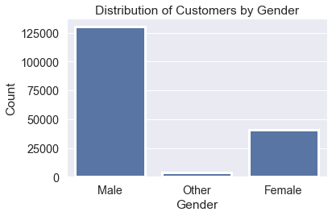

```python
sb.set(style='darkgrid', font_scale=1.3)
sb.countplot(x='member_gender', data=df, color='b', lw=3)
plt.xlabel('Gender')
plt.ylabel('Count')
plt.title("Distribution of Customers by Gender");
plt.tight_layout()
```

- Most user type is Subscriber

```python
df['user_type'].value_counts()
```

```
Subscriber    158386
Customer       16566
Name: user_type, dtype: int64
```

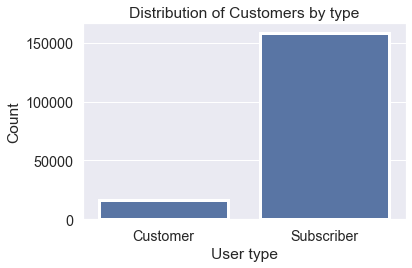

```python
sb.set(style='darkgrid', font_scale=1.3)
sb.countplot(x='user_type', data=df, color='b', lw=3)
plt.xlabel('User type')
plt.ylabel('Count')
plt.title("Distribution of Customers by type");
plt.tight_layout()
```

- Check member birth year so will corect 1878 to be 1978 as it isn't logic to be 143 years old

```python
df['member_birth_year'].value_counts()
```

```
1988.0    10214
1993.0     9323
1989.0     8967
1990.0     8640
1991.0     8484
          ...
1930.0        1
1910.0        1
1927.0        1
1928.0        1
1878.0        1
Name: member_birth_year, Length: 75, dtype: int64
```

```python
df.member_birth_year.replace({1878:1978}, inplace=True)
```

- From member birth year will add member age

```python
df['member_age'] = 2021 - df['member_birth_year']
df.head()
```

|  | duration_sec | start_time | end_time | start_station_id | start_station_name | start_station_latitude | start_station_longitude | end_station_id | end_station_name | end_station_latitude | end_station_longitude | bike_id | user_type | member_birth_year | member_gender | bike_share_for_all_trip | member_age |
| --- | --- | --- | --- | --- | --- | --- | --- | --- | --- | --- | --- | --- | --- | --- | --- | --- | --- |
| 0 | 52185 | 2019-02-28 17:32:10.1450 | 2019-03-01 08:01:55.9750 | 21.0 | Montgomery St BART Station (Market St at 2nd St) | 37.789625 | -122.400811 | 13.0 | Commercial St at Montgomery St | 37.794231 | -122.402923 | 4902 | Customer | 1984.0 | Male | No | 37.0 |
| 2 | 61854 | 2019-02-28 12:13:13.2180 | 2019-03-01 05:24:08.1460 | 86.0 | Market St at Dolores St | 37.769305 | -122.426826 | 3.0 | Powell St BART Station (Market St at 4th St) | 37.786375 | -122.404904 | 5905 | Customer | 1972.0 | Male | No | 49.0 |
| 3 | 36490 | 2019-02-28 17:54:26.0100 | 2019-03-01 04:02:36.8420 | 375.0 | Grove St at Masonic Ave | 37.774836 | -122.446546 | 70.0 | Central Ave at Fell St | 37.773311 | -122.444293 | 6638 | Subscriber | 1989.0 | Other | No | 32.0 |
| 4 | 1585 | 2019-02-28 23:54:18.5490 | 2019-03-01 00:20:44.0740 | 7.0 | Frank H Ogawa Plaza | 37.804562 | -122.271738 | 222.0 | 10th Ave at E 15th St | 37.792714 | -122.248780 | 4898 | Subscriber | 1974.0 | Male | Yes | 47.0 |
| 5 | 1793 | 2019-02-28 23:49:58.6320 | 2019-03-01 00:19:51.7600 | 93.0 | 4th St at Mission Bay Blvd S | 37.770407 | -122.391198 | 323.0 | Broadway at Kearny | 37.798014 | -122.405950 | 5200 | Subscriber | 1959.0 | Male | No | 62.0 |

```python
df['member_age'].value_counts()
```

```
33.0     10214
28.0      9323
32.0      8967
31.0      8640
30.0      8484
         ...
87.0         2
93.0         1
91.0         1
94.0         1
111.0        1
Name: member_age, Length: 74, dtype: int64
```

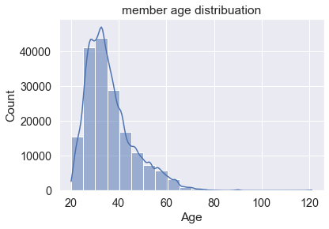

```python
sb.histplot(x='member_age', data=df,bins=20,kde=True);
plt.xlabel('Age');
plt.title('member age distribuation');
```

- The distribution is more concentrated between 20 to 40 years old.
- Check station & the top common station (top five )

```python
df.start_station_name.value_counts()
```

```
Market St at 10th St                                         3649
San Francisco Caltrain Station 2  (Townsend St at 4th St)    3408
Berry St at 4th St                                           2952
Montgomery St BART Station (Market St at 2nd St)             2711
Powell St BART Station (Market St at 4th St)                 2620
                                                             ...
Farnam St at Fruitvale Ave                                      9
Parker Ave at McAllister St                                     7
21st Ave at International Blvd                                  4
Palm St at Willow St                                            3
16th St Depot                                                   2
Name: start_station_name, Length: 329, dtype: int64
```

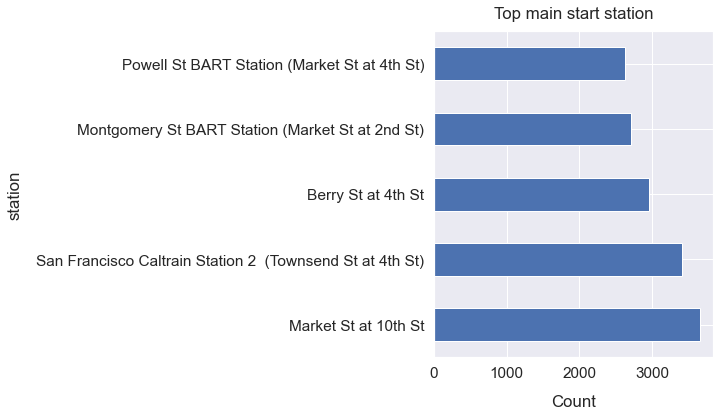

```python
#max_end_station = df.end_station_name.value_counts()[0:5]
#station = df.start_station_name.value_counts()[0:5]

sb.set(font_scale=1.4)
df['start_station_name'].value_counts()[0:5].plot(kind='barh', figsize=(5, 6), rot=0)
plt.ylabel("station", labelpad=14)
plt.xlabel("Count", labelpad=14)
plt.title("Top main start station", y=1.02);
```

```python
df.end_station_name.value_counts()
```

```
San Francisco Caltrain Station 2  (Townsend St at 4th St)    4624
Market St at 10th St                                         3709
Montgomery St BART Station (Market St at 2nd St)             3461
San Francisco Ferry Building (Harry Bridges Plaza)           3151
San Francisco Caltrain (Townsend St at 4th St)               2870
                                                             ...
Parker Ave at McAllister St                                     9
Palm St at Willow St                                            7
16th St Depot                                                   6
21st Ave at International Blvd                                  5
Willow St at Vine St                                            5
Name: end_station_name, Length: 329, dtype: int64
```

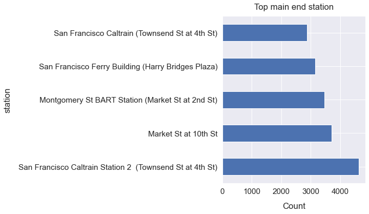

```python
sb.set(font_scale=1.4)
df['end_station_name'].value_counts()[0:5].plot(kind='barh', figsize=(5, 6), rot=0)
plt.ylabel("station", labelpad=14)
plt.xlabel("Count", labelpad=14)
plt.title("Top main end station", y=1.02);
```

- Adding all time details in below steps to check per day

```python
df['start_time']=pd.to_datetime(df['start_time'])
df['end_time']=pd.to_datetime(df['end_time'])
```

```python
df['hour']=df.start_time.dt.hour
df['day']=df.start_time.dt.day
df['weekday']=df.start_time.dt.day_name()
```

```python
df.head()
```

|  | duration_sec | start_time | end_time | start_station_id | start_station_name | start_station_latitude | start_station_longitude | end_station_id | end_station_name | end_station_latitude | end_station_longitude | bike_id | user_type | member_birth_year | member_gender | bike_share_for_all_trip | member_age | hour | day | weekday |
| --- | --- | --- | --- | --- | --- | --- | --- | --- | --- | --- | --- | --- | --- | --- | --- | --- | --- | --- | --- | --- |
| 0 | 52185 | 2019-02-28 17:32:10.145 | 2019-03-01 08:01:55.975 | 21.0 | Montgomery St BART Station (Market St at 2nd St) | 37.789625 | -122.400811 | 13.0 | Commercial St at Montgomery St | 37.794231 | -122.402923 | 4902 | Customer | 1984.0 | Male | No | 37.0 | 17 | 28 | Thursday |
| 2 | 61854 | 2019-02-28 12:13:13.218 | 2019-03-01 05:24:08.146 | 86.0 | Market St at Dolores St | 37.769305 | -122.426826 | 3.0 | Powell St BART Station (Market St at 4th St) | 37.786375 | -122.404904 | 5905 | Customer | 1972.0 | Male | No | 49.0 | 12 | 28 | Thursday |
| 3 | 36490 | 2019-02-28 17:54:26.010 | 2019-03-01 04:02:36.842 | 375.0 | Grove St at Masonic Ave | 37.774836 | -122.446546 | 70.0 | Central Ave at Fell St | 37.773311 | -122.444293 | 6638 | Subscriber | 1989.0 | Other | No | 32.0 | 17 | 28 | Thursday |
| 4 | 1585 | 2019-02-28 23:54:18.549 | 2019-03-01 00:20:44.074 | 7.0 | Frank H Ogawa Plaza | 37.804562 | -122.271738 | 222.0 | 10th Ave at E 15th St | 37.792714 | -122.248780 | 4898 | Subscriber | 1974.0 | Male | Yes | 47.0 | 23 | 28 | Thursday |
| 5 | 1793 | 2019-02-28 23:49:58.632 | 2019-03-01 00:19:51.760 | 93.0 | 4th St at Mission Bay Blvd S | 37.770407 | -122.391198 | 323.0 | Broadway at Kearny | 37.798014 | -122.405950 | 5200 | Subscriber | 1959.0 | Male | No | 62.0 | 23 | 28 | Thursday |

```python
df.weekday.value_counts()
```

```
Thursday     33712
Tuesday      30584
Wednesday    28426
Friday       27663
Monday       25641
Sunday       14512
Saturday     14414
Name: weekday, dtype: int64
```

```python
day_order = ['Thursday', 'Tuesday', 'Wednesday', 'Friday', 'Monday', 'Sunday', 'Saturday']
```

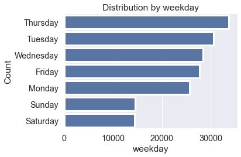

```python
sb.set(style='darkgrid', font_scale=1.3)
sb.countplot(y='weekday', data=df, color='b', lw=3 , order =day_order);
plt.xlabel('weekday')
plt.ylabel('Count')
plt.title("Distribution by weekday");
plt.tight_layout()
```

- Rides tend to decrease in weekends. This suggests that most of the rides are used at working days

```python
df.duration_sec.value_counts()
```

```
272      308
323      285
305      282
369      280
274      276
        ...
3145       1
7791       1
14880      1
3418       1
10661      1
Name: duration_sec, Length: 4429, dtype: int64
```

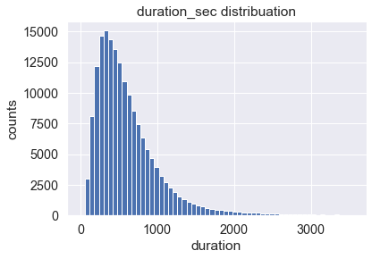

```python
bin_edges = np.arange(0, 3600, 60)
plt.hist(data = df, x = 'duration_sec', bins = bin_edges);
plt.title('duration_sec distribuation')
plt.xlabel('duration')
plt.ylabel('counts')
plt.show()
```

```python
df.bike_share_for_all_trip.value_counts()
```

```
No     157606
Yes     17346
Name: bike_share_for_all_trip, dtype: int64
```

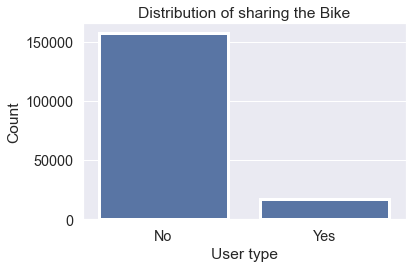

```python
sb.set(style='darkgrid', font_scale=1.3)
sb.countplot(x='bike_share_for_all_trip', data=df, color='b', lw=3)
plt.xlabel('User type')
plt.ylabel('Count')
plt.title("Distribution of sharing the Bike");
plt.tight_layout()
```

### Discuss the distribution(s) of your variable(s) of interest. Were there any unusual points? Did you need to perform any transformations?

The duration distribution right skewed

Most of the rides take place during weekdays (working days )

Most user are Subscriber

### Of the features you investigated, were there any unusual distributions? Did you perform any operations on the data to tidy, adjust, or change the form of the data? If so, why did you do this?

Fix year birth issue

Calcluate age to use it insted of year of birth

Adding day from start time column

which made easier

## Bivariate Exploration

> In this section, investigate relationships between pairs of variables in your data. Make sure the variables that you cover here have been introduced in some fashion in the previous section (univariate exploration).

Relationship between user type and bike share for all trip :

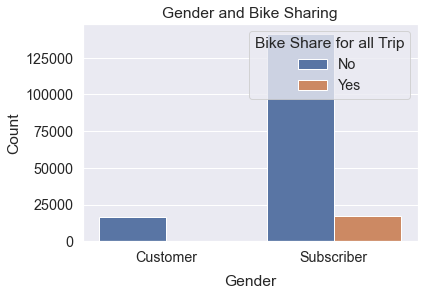

```python
sb.countplot(data=df,x='user_type',hue='bike_share_for_all_trip')
plt.xlabel('Gender',labelpad=10)
plt.ylabel('Count')
plt.legend(title='Bike Share for all Trip')
plt.title('Gender and Bike Sharing');
```

- Bike share option available only for Subscriber

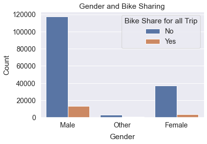

```python
sb.countplot(data=df,x='member_gender',hue='bike_share_for_all_trip')
plt.xlabel('Gender',labelpad=10)
plt.ylabel('Count')
plt.legend(title='Bike Share for all Trip')
plt.title('Gender and Bike Sharing');
```

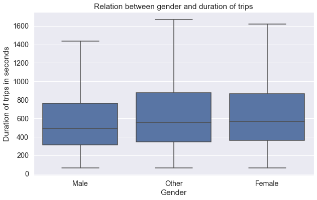

```python
# Using boxplot to visual the relation
plt.figure(figsize=[10,6])
color = sb.color_palette()[0]
sb.boxplot(data=df, x='member_gender', y='duration_sec', color=color, showfliers=False);
plt.title('Relation between gender and duration of trips');
plt.ylabel('Duration of trips in seconds');
plt.xlabel('Gender');
```

- female and other rides longer trips than males

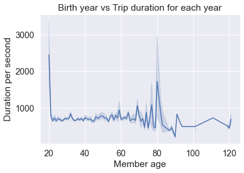

```python
sb.lineplot(x='member_age', y='duration_sec', data=df);
plt.xlabel('Member age');
plt.ylabel('Duration per second');
plt.title('Birth year vs Trip duration for each year');
```

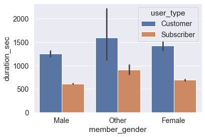

```python
sb.barplot(x='member_gender', y='duration_sec',
            data=df,
            hue='user_type'
           );
```

```python
df.groupby(['member_gender', 'user_type']).duration_sec.count()
```

```
member_gender  user_type
Female         Customer        4623
               Subscriber     36182
Male           Customer       11493
               Subscriber    119007
Other          Customer         450
               Subscriber      3197
Name: duration_sec, dtype: int64
```

```python
total = df.shape[0]

total_M = df.member_gender[df.member_gender == 'Male'].count()
total_F = df.member_gender[df.member_gender == 'Female'].count()
total_O = df.member_gender[df.member_gender == 'Other'].count()

M_subscribers = df.member_gender[(df.member_gender == 'Male')&(df.user_type == 'Subscriber')].count()
F_subscribers = df.member_gender[(df.member_gender == 'Female')&(df.user_type == 'Subscriber')].count()
O_subscribers = df.member_gender[(df.member_gender == 'Other')&(df.user_type == 'Subscriber')].count()

M_customers = df.member_gender[(df.member_gender == 'Male')&~(df.user_type == 'Subscriber')].count()
F_customers = df.member_gender[(df.member_gender == 'Female')&~(df.user_type == 'Subscriber')].count()
O_customers = df.member_gender[(df.member_gender == 'Other')&~(df.user_type == 'Subscriber')].count()

M_subscribers_prop = M_subscribers / total_M
F_subscribers_prop = F_subscribers  / total_F
O_subscribers_prop = O_subscribers / total_O

M_customers_prop = M_customers / total_M
F_customers_prop = F_customers / total_F
O_customers_prop = O_customers / total_O

print(M_subscribers_prop)
print(F_subscribers_prop)

print(M_customers_prop)
print(F_customers_prop)
```

```
0.9119310344827586
0.8867050606543315
0.08806896551724137
0.11329493934566842
```

### Did you observe any interesting relationships between the other features (not the main feature(s) of interest)?

> Your answer here!
- User type wasn't clear enough so adding gender also to check effect

## Multivariate Exploration

> Create plots of three or more variables to investigate your data even further. Make sure that your investigations are justified, and follow from your work in the previous sections.
- Relation between age of and duration gender

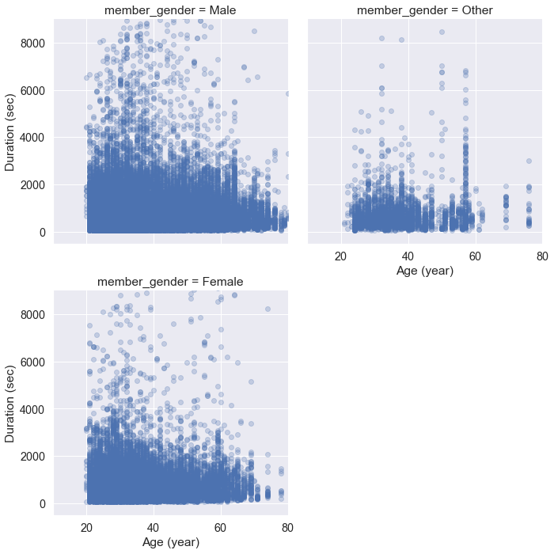

```python
gender = sb.FacetGrid(data = df, col = 'member_gender', col_wrap = 2, size = 5,
                 xlim = [10, 80], ylim = [-500, 9000])
gender.map(plt.scatter, 'member_age', 'duration_sec', alpha=0.25)
gender.set_xlabels('Age (year)')
gender.set_ylabels('Duration (sec)')

plt.show()
```

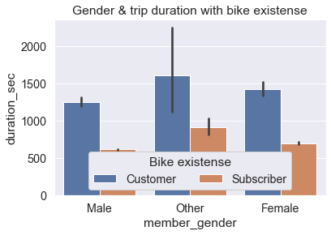

```python
ax = sb.barplot(data = df, x = 'member_gender', y = 'duration_sec', hue = 'user_type')
ax.legend(loc = 8, ncol = 3, framealpha = 1, title = 'Bike existense');
plt.title('Gender & trip duration with bike existense');
```

- comparing between customers and subscribers have less variance in ride duration with age also more average ride duration.

### Were there any interesting or surprising interactions between features?

> At the end of your report, make sure that you export the notebook as an html file from the `File > Download as... > HTML` menu. Make sure you keep track of where the exported file goes, so you can put it in the same folder as this notebook for project submission. Also, make sure you remove all of the quote-formatted guide notes like this one before you finish your report!